# Pokemon

#### In this project, we'll use a dataset from Kaggle that contains information about Pokemon.

#### Link to dataset: https://www.kaggle.com/rounakbanik/pokemon

### Step 1: Defining the Problem

#### Our goal is to analyze the Pokemon dataset and gain insights into the characteristics of different types of Pokemon. Specifically, we want to answer the following questions:

#### 1- Which type of Pokemon is the strongest based on their overall stats?

#### 2- How does the distribution of different Pokemon types compare?

#### 3- What is the correlation between the different Pokemon stats?

#### 4- What is the most common primary and secondary type combination?

#### 5- Which Pokemon has the highest and lowest total stats?

#### 6- How does the 'Total' stat vary for each Pokemon type?

#### 7- Which Pokemon has the highest and lowest speed?

#### 8- How does the 'Speed' stat vary for each Pokemon type?

#### 9- Is there a correlation between the 'Legendary' status of a Pokemon and its 'Total' stats?

### Step 2: Loading the Dataset

#### Let's start by loading the Pokemon dataset into a Pandas DataFrame:

```python
import pandas as pd

df = pd.read_csv(r'C:\Users\Baazz\Downloads\pokemon.csv')
```

### Step 3: Exploratory Data Analysis

#### Before we start answering our questions, let's take a look at the dataset and perform some exploratory data analysis to gain insights and identify any issues or missing data. Here are some questions we can ask:

#### 1. How many rows and columns does the dataset have?

```python
print('Shape of dataset:', df.shape)
```

```
Shape of dataset: (801, 42)
```

#### 2. What are the data types of each column?

```python
print('Data types of columns:')
print(df.dtypes)
```

```
Data types of columns:
abilities             object
against_bug          float64
against_dark         float64
against_dragon       float64
against_electric     float64
against_fairy        float64
against_fight        float64
against_fire         float64
against_flying       float64
against_ghost        float64
against_grass        float64
against_ground       float64
against_ice          float64
against_normal       float64
against_poison       float64
against_psychic      float64
against_rock         float64
against_steel        float64
against_water        float64
attack                 int64
base_egg_steps         int64
base_happiness         int64
base_total             int64
capture_rate          object
classfication         object
defense                int64
experience_growth      int64
height_m             float64
hp                     int64
japanese_name         object
name                  object
percentage_male      float64
pokedex_number         int64
sp_attack              int64
sp_defense             int64
speed                  int64
Total                  int64
type1                 object
type2                 object
weight_kg            float64
generation             int64
is_legendary           int64
dtype: object
```

#### 3. Are there any missing values in the dataset?

```python
print('Missing values in dataset:')
print(df.isnull().sum())
```

```
Missing values in dataset:
abilities              0
against_bug            0
against_dark           0
against_dragon         0
against_electric       0
against_fairy          0
against_fight          0
against_fire           0
against_flying         0
against_ghost          0
against_grass          0
against_ground         0
against_ice            0
against_normal         0
against_poison         0
against_psychic        0
against_rock           0
against_steel          0
against_water          0
attack                 0
base_egg_steps         0
base_happiness         0
base_total             0
capture_rate           0
classfication          0
defense                0
experience_growth      0
height_m              20
hp                     0
japanese_name          0
name                   0
percentage_male       98
pokedex_number         0
sp_attack              0
sp_defense             0
speed                  0
Total                  0
type1                  0
type2                384
weight_kg             20
generation             0
is_legendary           0
dtype: int64
```

#### 4. What are the unique values in each column?

```python
print('Unique values in each column:')
for col in df.columns:
    print(col, df[col].nunique())
```

```
Unique values in each column:
abilities 482
against_bug 5
against_dark 5
against_dragon 4
against_electric 6
against_fairy 5
against_fight 6
against_fire 5
against_flying 5
against_ghost 5
against_grass 5
against_ground 6
against_ice 5
against_normal 4
against_poison 6
against_psychic 6
against_rock 5
against_steel 5
against_water 5
attack 114
base_egg_steps 10
base_happiness 6
base_total 203
capture_rate 34
classfication 588
defense 109
experience_growth 6
height_m 51
hp 99
japanese_name 801
name 801
percentage_male 7
pokedex_number 801
sp_attack 111
sp_defense 97
speed 113
Total 215
type1 18
type2 18
weight_kg 421
generation 7
is_legendary 2
```

#### 5. What are the summary statistics for each column?

```python
print('Summary statistics for each column:')
print(df.describe())
```

```
Summary statistics for each column:
       against_bug  against_dark  against_dragon  against_electric  \
count   801.000000    801.000000      801.000000        801.000000
mean      0.996255      1.057116        0.968789          1.073970
std       0.597248      0.438142        0.353058          0.654962
min       0.250000      0.250000        0.000000          0.000000
25%       0.500000      1.000000        1.000000          0.500000
50%       1.000000      1.000000        1.000000          1.000000
75%       1.000000      1.000000        1.000000          1.000000
max       4.000000      4.000000        2.000000          4.000000

       against_fairy  against_fight  against_fire  against_flying  \
count     801.000000     801.000000    801.000000      801.000000
mean        1.068976       1.065543      1.135456        1.192884
std         0.522167       0.717251      0.691853        0.604488
min         0.250000       0.000000      0.250000        0.250000
25%         1.000000       0.500000      0.500000        1.000000
50%         1.000000       1.000000      1.000000        1.000000
75%         1.000000       1.000000      2.000000        1.000000
max         4.000000       4.000000      4.000000        4.000000

       against_ghost  against_grass  ...          hp  percentage_male  \
count     801.000000     801.000000  ...  801.000000       703.000000
mean        0.985019       1.034020  ...   68.958801        55.155761
std         0.558256       0.788896  ...   26.576015        20.261623
min         0.000000       0.250000  ...    1.000000         0.000000
25%         1.000000       0.500000  ...   50.000000        50.000000
50%         1.000000       1.000000  ...   65.000000        50.000000
75%         1.000000       1.000000  ...   80.000000        50.000000
max         4.000000       4.000000  ...  255.000000       100.000000

       pokedex_number   sp_attack  sp_defense       speed       Total  \
count      801.000000  801.000000  801.000000  801.000000  801.000000
mean       401.000000   71.305868   70.911361   66.334582  208.551810
std        231.373075   32.353826   27.942501   28.907662   69.095876
min          1.000000   10.000000   20.000000    5.000000   65.000000
25%        201.000000   45.000000   50.000000   45.000000  158.000000
50%        401.000000   65.000000   66.000000   65.000000  205.000000
75%        601.000000   91.000000   90.000000   85.000000  255.000000
max        801.000000  194.000000  230.000000  180.000000  454.000000

        weight_kg  generation  is_legendary
count  781.000000  801.000000    801.000000
mean    61.378105    3.690387      0.087391
std    109.354766    1.930420      0.282583
min      0.100000    1.000000      0.000000
25%      9.000000    2.000000      0.000000
50%     27.300000    4.000000      0.000000
75%     64.800000    5.000000      0.000000
max    999.900000    7.000000      1.000000

[8 rows x 35 columns]
```

### Step 4: Answering the Questions

#### Now that we have a better understanding of the dataset, let's start answering our questions:

#### 1- Which type of Pokemon is the strongest based on their overall stats?

```python
df['Total'] = df.iloc[:, 4:10].sum(axis=1)
type_totals = df.groupby('type1')['Total'].mean()
strongest_type = type_totals.sort_values(ascending=False).index[0]

print('The strongest type of Pokemon is', strongest_type)
```

[output not shown]

#### 2- How does the distribution of different Pokemon types compare?

#### To answer this question, we can create a bar chart that shows the count of each Pokemon type in the dataset.

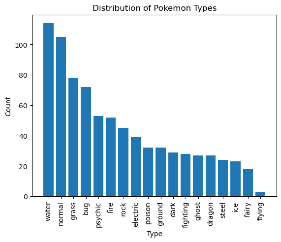

```python
import matplotlib.pyplot as plt

type_counts = df['type1'].value_counts()
plt.bar(type_counts.index, type_counts.values)
plt.xticks(rotation=90)
plt.xlabel('Type')
plt.ylabel('Count')
plt.title('Distribution of Pokemon Types')
plt.show()
```

#### The output of this code shows us a bar chart that visualizes the distribution of Pokemon types in the dataset.

#### 3- What is the correlation between the different Pokemon stats?

[figure not shown]

```python
import seaborn as sns

corr_matrix = df.iloc[:, 4:10].corr()
sns.heatmap(corr_matrix, annot=True, cmap='coolwarm')
plt.title('Correlation Matrix for Pokemon Stats')
plt.show()
```

#### The output of this code shows us a heatmap that visualizes the correlation matrix.

#### 4- What is the most common primary and secondary type combination?

#### To answer this question, we can create a new column in our DataFrame called 'Type Combination', which combines the 'Type 1' and 'Type 2' columns. Then, we can count the number of Pokemon for each type combination and find the most common one.

```python
df['Type Combination'] = df['type1'] + '-' + df['type2'].fillna('')
type_comb_counts = df['Type Combination'].value_counts()
most_common_comb = type_comb_counts.index[0]

print('The most common primary and secondary type combination is', most_common_comb)
```

```
The most common primary and secondary type combination is normal-
```

#### 5- Which Pokemon has the highest and lowest total stats?

#### To answer this question, we can find the Pokemon with the highest and lowest 'Total' values in our DataFrame.

```python
highest_total_pokemon = df.loc[df['Total'].idxmax(), 'name']
lowest_total_pokemon = df.loc[df['Total'].idxmin(), 'name']

print('The Pokemon with the highest total stats is', highest_total_pokemon)
print('The Pokemon with the lowest total stats is', lowest_total_pokemon)
```

[output not shown]

#### 6- How does the 'Total' stat vary for each Pokemon type?

#### To answer this question, we can create a box plot that shows the distribution of 'Total' values for each Pokemon type.

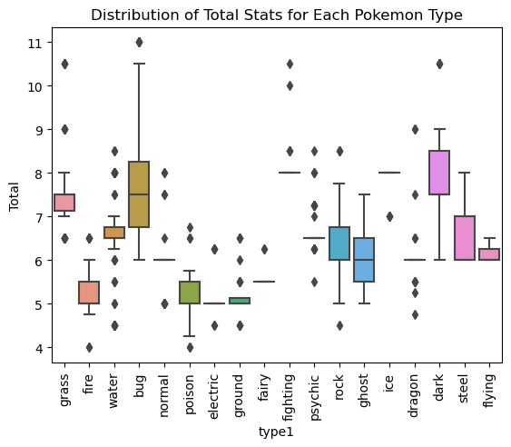

```python
sns.boxplot(x='type1', y='Total', data=df)
plt.xticks(rotation=90)
plt.title('Distribution of Total Stats for Each Pokemon Type')
plt.show()
```

#### The output of this code shows us a box plot that visualizes the distribution of 'Total' values for each Pokemon type.

#### These additional analyses help us gain a deeper understanding of the Pokemon dataset and the characteristics of different Pokemon.

#### 7- Which Pokemon has the highest and lowest speed?

#### To answer this question, we can find the Pokemon with the highest and lowest 'Speed' values in our DataFrame.

```python
highest_speed_pokemon = df.loc[df['speed'].idxmax(), 'name']
lowest_speed_pokemon = df.loc[df['speed'].idxmin(), 'name']

print('The Pokemon with the highest speed is', highest_speed_pokemon)
print('The Pokemon with the lowest speed is', lowest_speed_pokemon)
```

```
The Pokemon with the highest speed is Deoxys
The Pokemon with the lowest speed is Shuckle
```

#### 8- How does the 'Speed' stat vary for each Pokemon type?

#### To answer this question, we can create a box plot that shows the distribution of 'Speed' values for each Pokemon type.

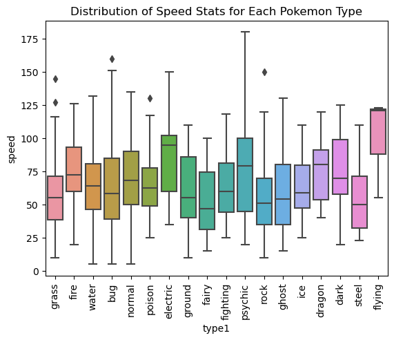

```python
sns.boxplot(x='type1', y='speed', data=df)
plt.xticks(rotation=90)
plt.title('Distribution of Speed Stats for Each Pokemon Type')
plt.show()
```

#### The output of this code shows us a box plot that visualizes the distribution of 'speed' values for each Pokemon type.

#### 9- Is there a correlation between the 'Legendary' status of a Pokemon and its 'Total' stats?

#### To answer this question, we can create a scatter plot that shows the relationship between the 'Legendary' and 'Total' columns.

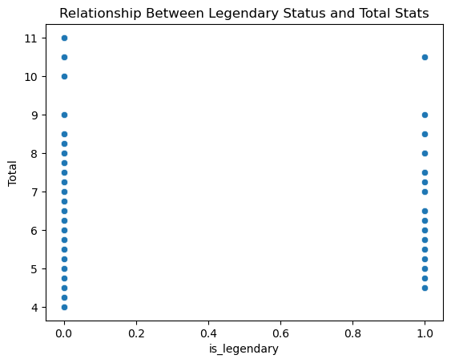

```python
sns.scatterplot(x='is_legendary', y='Total', data=df)
plt.title('Relationship Between Legendary Status and Total Stats')
plt.show()
```

#### The output of this code shows us a scatter plot that visualizes the relationship between the 'Legendary' and 'Total' columns.

### Step 5: Insights:

#### 8.The distribution of speed stats also varies for each Pokemon type, with some types having a wider range of speed stats than others.